# Estimating the number of off grid households

Scotland

Ben Anderson (b.anderson@soton.ac.uk `@dataknut`)

Last run at: 2020-03-30 12:10:49

> Citation

If you wish to use any of the material from this report please cite as:

- Anderson, B.(2020) Estimating the number of off grid households: Scotland, SERG: University of Southampton.

# 1 About

Circulation:

- Public

## 1.1 Purpose

This report is intended to:

- estimate the number of off-grid households in Scotland;
- with a specific focus on the Highlands & Islands

This work was carried out by the [Sustainable Energy Research Group](http://www.energy.soton.ac.uk) in the University of Southampton’s [Faculty of Engineering and Environment](http://www.southampton.ac.uk/engineering/index.page).

## 1.2 History

Generally tracked via [github](https://github.com/dataknut/offGrid/commits/master)

## 1.3 Re-use

The work is (c) 2020 the University of Southampton.

The work is published under the Creative Commons Attribution-ShareAlike 4.0 International ([CC BY-SA 4.0](https://creativecommons.org/licenses/by-sa/4.0/)) License.

- You are free to:
  - Share — copy and redistribute the material in any medium or format;
  - Adapt — remix, transform, and build upon the material;
- for any purpose, even commercially.

Under the following terms:

- Attribution — You must give appropriate credit, provide a link to the license, and indicate if changes were made. You may do so in any reasonable manner, but not in any way that suggests the licensor endorses you or your use.
- ShareAlike — If you remix, transform, or build upon the material, you must distribute your contributions under the same license as the original.
- No additional restrictions — You may not apply legal terms or technological measures that legally restrict others from doing anything the license permits.

Re-use of the software code contained within this work is governed by an additional [license](https://github.com/dataknut/offGrid/blob/master/LICENSE).

# 2 Introduction

It started with a tweet:

- https://twitter.com/hannon_matthew/status/1242790919818153984

# 3 Data used

- Census 2011 data on the [number of household spaces for Scotland at datazone level](https://www.scotlandscensus.gov.uk/ods-web/download/getDownloadFile.html?downloadFileIds=SNS%20Data%20Zone%202011%20blk);
- BEIS 2010 - 2018 data on the [number of electricty meters at datazone level](https://www.gov.uk/government/collections/sub-national-electricity-consumption-data).

# 4 Method 1: counting meters

If we assume:

- the number of household spaces off grid = n household spaces - n meters

Then in theory we can estimate the number who are off grid. Of course some may be ‘off grid’ but still have a meter. And it is crucial that we have an accurate estimate of the number of household spaces to match to the BEIS data. Of course we only have that at datazone level for 2011…as we will see.

Here’s the code - just to be sure!

```r
# subtract n elec meters from n household spaces

t <- censusDT[, .(zonecode, `Unoccupied household spaces: Total`, `Occupied household spaces`, `All household spaces`,
    nHHspaces2011)]
t <- t[order(zonecode)]

kableExtra::kable(head(t), caption = "Census data check (first 6 rows)") %>% kable_styling()
```

Table 4.1: Census data check (first 6 rows)

| zonecode | Unoccupied household spaces: Total | Occupied household spaces | All household spaces | nHHspaces2011 |
| --- | --- | --- | --- | --- |
| S01006506 | 28 | 424 | 452 | 452 |
| S01006507 | 1 | 364 | 365 | 365 |
| S01006508 | 11 | 340 | 351 | 351 |
| S01006509 | 8 | 274 | 282 | 282 |
| S01006510 | 12 | 256 | 268 | 268 |
| S01006511 | 3 | 315 | 318 | 318 |

```r
t <- beisDT[, .(zonecode, METERS)]
t <- t[order(zonecode)]

kableExtra::kable(head(t), caption = "BEIS data check (first 6 rows)") %>% kable_styling()
```

Table 4.1: BEIS data check (first 6 rows)

| zonecode | METERS |
| --- | --- |
| E01000001 | 1058 |
| E01000001 | 1058 |
| E01000001 | 1057 |
| E01000001 | 1057 |
| E01000001 | 1057 |
| E01000001 | 1058 |

```r
scotlandDT[, `:=`(estimatednHHSpacesOffGrid, nHHspaces2011 - METERS)]
scotlandDT[, `:=`(estimatedPcHHSpacesOffGrid, 100 * (estimatednHHSpacesOffGrid/nHHspaces2011))]
```

## 4.1 Results

### 4.1.1 2011

This should be the ‘most accurate’ year as the data sources match.

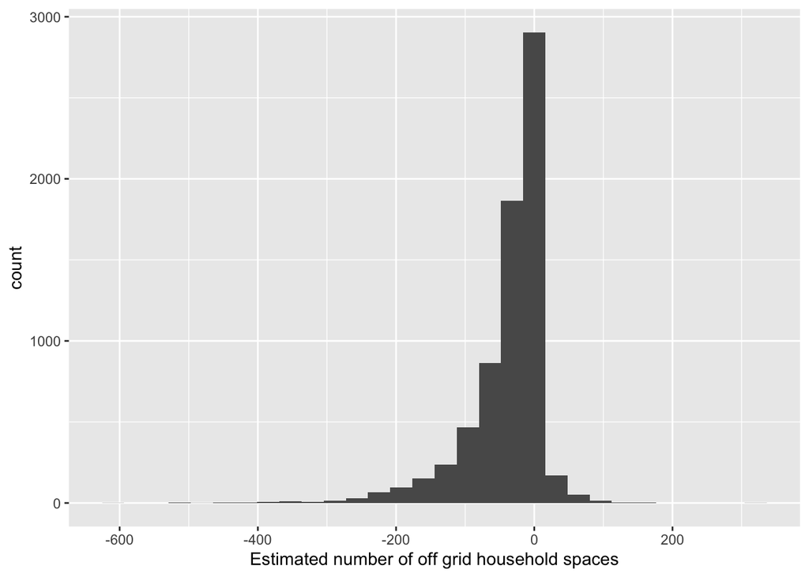

Figure 4.1: Histogram of Estimated number of off grid household spaces in Scotland in 2011

Well, that’s already interesting. We seem to have more meters than household spaces in a lot of places.

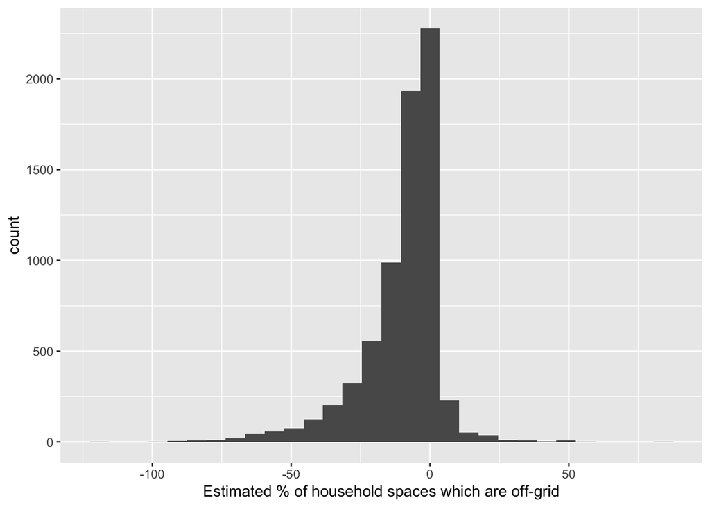

Figure 4.2: Histogram of estimated percentage of household spaces which are off grid in Scotland in 2011

Naturally this turns itself into some quite large negative percentages (Figure 4.2). Where are they and do they make any sense?

Table 4.2: Ten largest negative estimates

| LAName | LSOAName | METERS | nHHspaces2011 | estimatedPcHHSpacesOffGrid |
| --- | --- | --- | --- | --- |
| Glasgow City | Wyndford - 01 | 1160 | 538 | -115.61338 |
| Aberdeen City | City Centre East - 02 | 701 | 351 | -99.71510 |
| Dundee City | Perth Road - 03 | 1030 | 532 | -93.60902 |
| Fife | Pitreavie Castle West | 350 | 182 | -92.30769 |
| West Dunbartonshire | IZ11 - 01 | 573 | 299 | -91.63880 |
| South Lanarkshire | Burnside and Springhall - 04 | 509 | 270 | -88.51852 |
| Shetland Islands | North and East Isles - 02 | 800 | 428 | -86.91589 |
| Dundee City | Linlathen and Midcraigie - 03 | 381 | 205 | -85.85366 |
| Dundee City | Hilltown - 04 | 1103 | 594 | -85.69024 |
| North Ayrshire | Arran - 04 | 566 | 306 | -84.96732 |

Table 4.3: Summary by local authority

| LAName | nZones | meanMeters | meanHHspaces | mean_pc_offgrid | min_pc_offgrid | max_pc_offgrid |
| --- | --- | --- | --- | --- | --- | --- |
| Shetland Islands | 30 | 570.0333 | 354.2000 | -59.93907 | -86.91589 | -34.834835 |
| Orkney Islands | 29 | 481.6207 | 357.1379 | -36.06931 | -71.25000 | -8.945687 |
| Na h-Eileanan Siar | 36 | 519.5000 | 384.9167 | -34.44336 | -57.99257 | -12.558139 |
| Argyll and Bute | 125 | 468.8240 | 368.5840 | -25.25209 | -64.01447 | 17.241379 |
| Highland | 312 | 442.7917 | 357.1795 | -22.92455 | -75.07692 | 5.362776 |
| Dundee City | 188 | 461.7021 | 380.9840 | -20.25157 | -93.60902 | 3.184713 |
| Perth and Kinross | 186 | 428.1129 | 368.6989 | -15.20438 | -56.87023 | 7.657658 |
| Scottish Borders | 143 | 448.3916 | 392.9231 | -13.50577 | -45.45455 | 24.179105 |
| Angus | 155 | 395.2065 | 346.5290 | -13.03347 | -54.02299 | 21.315790 |
| Aberdeen City | 283 | 435.0318 | 382.1661 | -12.44240 | -99.71510 | 12.307692 |

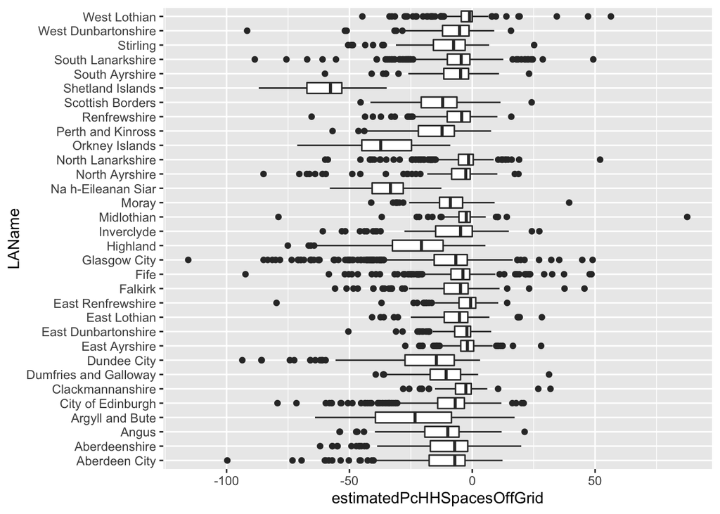

Figure 4.3: Boxplot of estimated % of households off-grid by local authority

Well, Figure 4.3 makes no sense to me at all. It suggets that the median off-grid % in all local authorities in Scotland is slightly negative. Shetland & Orkneys are outliers. We might have expected them to be outliers in the other direction. Did we get our maths wrong? Not according to Table 4.2…

### 4.1.2 2018

Let’s got to the other extreme and repeat. By now we are 7 years since Census 2011 so our household space counts should be well out of date.

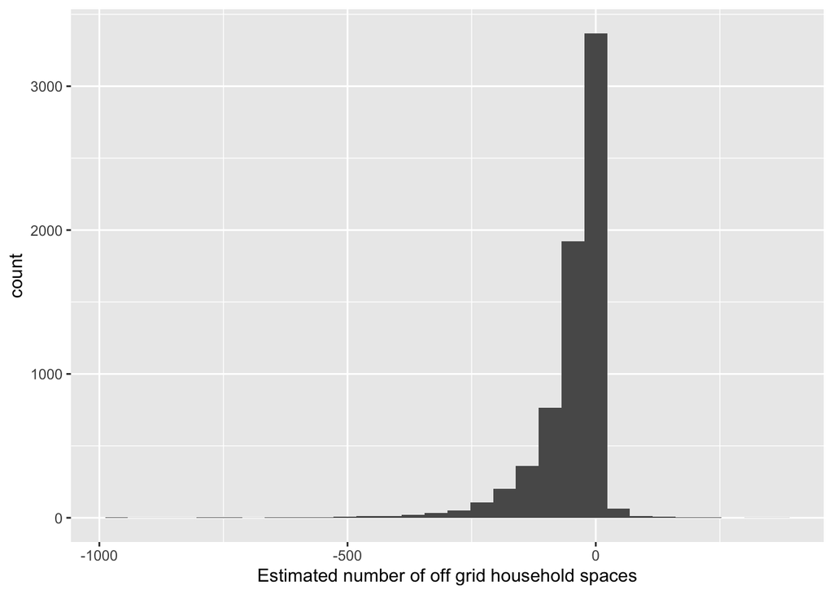

Figure 4.4: Histogram of Estimated number of off grid household spaces in Scotland in 2018

Much the same.

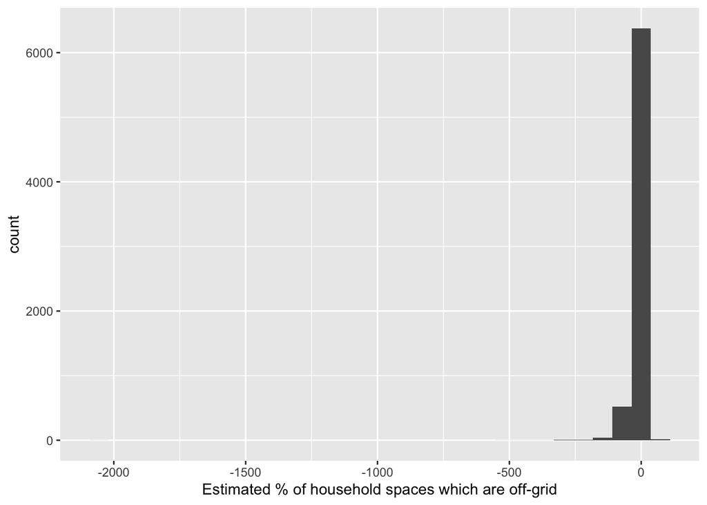

Figure 4.5: Histogram of estimated percentage of household spaces which are off grid in Scotland in 2018

Figure 4.5 has got some very large negative values!

Table 4.4: Ten largest negative estimates

| LAName | LSOAName | METERS | nHHspaces2011 | estimatedPcHHSpacesOffGrid |
| --- | --- | --- | --- | --- |
| West Lothian | Whitburn, Croftmalloch and Greenrigg - 03 | 814 | 38 | -2042.1053 |
| Midlothian | Newbattle and Dalhousie - 07 | 1151 | 199 | -478.3920 |
| Falkirk | Reddingmuirhead and Overton - 04 | 720 | 130 | -453.8462 |
| East Renfrewshire | Crookfur and Fruin - 01 | 1214 | 246 | -393.4959 |
| Aberdeenshire | Longside and Rattray - 03 | 818 | 199 | -311.0553 |
| East Dunbartonshire | Rosebank and Waterside - 04 | 930 | 230 | -304.3478 |
| Renfrewshire | Renfrewshire Rural North and Langbank - 03 | 1075 | 271 | -296.6790 |
| Moray | Heldon West, Fogwatt to Inchberry - 03 | 979 | 248 | -294.7581 |
| Fife | Leuchatsbeath | 507 | 133 | -281.2030 |
| Fife | South Fod and Calais Muir | 693 | 183 | -278.6885 |

Table 4.5: Summary by local authority

| LAName | nZones | meanMeters | meanHHspaces | mean_pc_offgrid | min_pc_offgrid | max_pc_offgrid |
| --- | --- | --- | --- | --- | --- | --- |
| Shetland Islands | 30 | 580.5667 | 354.2000 | -64.16797 | -118.84817 | -34.234234 |
| Orkney Islands | 29 | 503.6207 | 357.1379 | -42.59125 | -96.35762 | -12.460064 |
| Na h-Eileanan Siar | 36 | 515.6389 | 384.9167 | -33.42224 | -58.37696 | -9.069767 |
| Highland | 312 | 451.2885 | 357.1795 | -26.06498 | -211.70732 | 2.839117 |
| Argyll and Bute | 125 | 469.0320 | 368.5840 | -25.45992 | -101.39373 | 9.578544 |
| Perth and Kinross | 186 | 432.1398 | 368.6989 | -16.78188 | -118.72510 | 5.394191 |
| West Lothian | 239 | 342.0335 | 313.2385 | -16.62576 | -2042.10526 | 17.666667 |
| Aberdeenshire | 340 | 370.2118 | 322.1882 | -15.76638 | -311.05528 | 22.429907 |
| Aberdeen City | 283 | 444.9046 | 382.1661 | -15.57196 | -229.72028 | 41.651032 |
| City of Edinburgh | 597 | 445.3484 | 385.5930 | -15.49116 | -253.49544 | 16.913947 |

[figure not shown]

Figure 4.6: Boxplot of estimated % of households off-grid by local authority

Figure 4.6 is just as curious…

Did we get our maths wrong? Not according to Table 4.4…

## 4.2 Conclusion

Don’t you hate it when a good idea goes belly-up.

So what’s going on? The [BEIS methodology report](https://assets.publishing.service.gov.uk/government/uploads/system/uploads/attachment_data/file/853104/sub-national-methodology-guidance.pdf) says:

> The number of meters does not exactly equal the number of properties. The reasons for this are as follows:
> 1. An apartment building may have a meter for the building complex (used to power communal electricity uses such as lighting) in addition to each individual apartment having its own meter.
> 2. Some households may have a 3-rate meter system. A household with such a system will have one meter which measures all consumption at a peak rate and another meter which measures two other rates of off-peak consumption. This is the case for many households in Scotland, but it is less common to find a similar case in England or Wales.

So that’s why…

Now what?

- ask BEIS to provide a count of properties with meters instead of just a count of meters? This must be possible because the [BEIS methodology document](https://www.gov.uk/government/publications/regional-energy-data-guidance-note) states:

> “Meter postcode address file from ECOES: Geographic data is obtained for each meter from the Electricity Central Online Enquiry Service (ECOES) data file, which includes the address and postcode of each MPAN.”

# 5 Method 2 - using ‘old’ data

Previous versions of the LSOA/datazone level data (which no longer seem to be available from the BEIS [website](https://www.gov.uk/government/statistics/lower-and-middle-super-output-areas-electricity-consumption)) had more detail:

```
##  [1] "Local Authority Name"
##  [2] "Local Authority Code"
##  [3] "Middle Layer Super Output Area (MLSOA) Code"
##  [4] "Lower Layer Super Output Area (LLSOA) Code"
##  [5] "Ordinary Domestic Consumption (kWh)"
##  [6] "Economy 7 Consumption (kWh)"
##  [7] "Total domestic electricity consumption (kWh)"
##  [8] "Number of Ordinary Domestic Meters"
##  [9] "Number of Economy 7 Meters"
## [10] "Total number of domestic electricity meters"
## [11] " Average Ordinary consumption \r(kWh per meter) "
## [12] "Average Economy 7 consumption (kWh per meter)"
## [13] " Average domestic electricity consumption \r(kWh per meter) "
```

```
##    Local Authority Name Local Authority Code Middle Layer Super Output Area (MLSOA) Code
## 1: Barking and Dagenham              UKI2101                                   E02000016
## 2:               Bexley              UKI2102                                   E02000066
## 3:                Brent              UKI2302                                   E02000107
## 4:                Brent              UKI2302                                   E02000119
## 5:               Camden              UKI1102                                   E02000180
## 6:               Camden              UKI1102                                   E02000172
##      Lower Layer Super Output Area (LLSOA) Code Ordinary Domestic Consumption (kWh)
## 1:                      E01000008, Unallocated
## 2:  E01000464, E01000465, E01000422, E01000470
## 3:                        E01000555, E01000553
## 4:                        E01000599, E01000597
## 5:                        E01000868, E01000865
## 6:                        E01000890, E01000891
##    Economy 7 Consumption (kWh) Total domestic electricity consumption (kWh)
```

[output cut: 41 more lines]

```
## New data: zonecodes beginning with 'S' (Scotland)
```

```
##    METERS  zonecode        LAName
## 1:    480 S01006506 Aberdeen City
## 2:    402 S01006507 Aberdeen City
## 3:    397 S01006508 Aberdeen City
## 4:    307 S01006509 Aberdeen City
## 5:    312 S01006510 Aberdeen City
## 6:    322 S01006511 Aberdeen City
```

```
## Old data: zonecodes beginning with 'S' (Scotland)
```

```
## Empty data.table (0 rows and 14 cols): Local Authority Name,Local Authority Code,Middle Layer Super Output Area (MLSOA) Code,Lower Layer Super Output Area (LLSOA) Code,Ordinary Domestic Consumption (kWh),Economy 7 Consumption (kWh)...
```

Nope. The old data does not include Scotland…

# 6 Annex

## 6.1 Data summaries

Census

(#tab:skim.census)Data summary

| Name | censusDT |
| --- | --- |
| Number of rows | 6976 |
| Number of columns | 9 |
| _______________________ |  |
| Column type frequency: |  |
| character | 3 |
| numeric | 6 |
| ________________________ |  |
| Group variables | None |

**Variable type: character**

| skim_variable | n_missing | complete_rate | min | max | empty | n_unique | whitespace |
| --- | --- | --- | --- | --- | --- | --- | --- |
| V1 | 0 | 1 | 9 | 9 | 0 | 6976 | 0 |
| V2 | 0 | 1 | 20 | 20 | 0 | 1 | 0 |
| zonecode | 0 | 1 | 9 | 9 | 0 | 6976 | 0 |

**Variable type: numeric**

| skim_variable | n_missing | complete_rate | mean | sd | p0 | p25 | p50 | p75 | p100 | hist |
| --- | --- | --- | --- | --- | --- | --- | --- | --- | --- | --- |
| All household spaces | 0 | 1 | 354.63 | 95.54 | 38 | 286 | 345 | 413.00 | 905 | ▁▇▃▁▁ |
| Occupied household spaces | 0 | 1 | 340.13 | 89.24 | 36 | 276 | 332 | 394.25 | 817 | ▁▇▆▁▁ |
| Unoccupied household spaces: Total | 0 | 1 | 14.49 | 20.16 | 0 | 5 | 9 | 16.00 | 425 | ▇▁▁▁▁ |
| Unoccupied household spaces: Second residence/holiday accommodation | 0 | 1 | 5.25 | 16.31 | 0 | 0 | 1 | 3.00 | 390 | ▇▁▁▁▁ |
| Unoccupied household spaces: Vacant | 0 | 1 | 9.24 | 9.94 | 0 | 4 | 7 | 12.00 | 197 | ▇▁▁▁▁ |
| nHHspaces2011 | 0 | 1 | 354.63 | 95.54 | 38 | 286 | 345 | 413.00 | 905 | ▁▇▃▁▁ |

BEIS

(#tab:skim.beis)Data summary

| Name | beisDT |
| --- | --- |
| Number of rows | 375535 |
| Number of columns | 12 |
| _______________________ |  |
| Column type frequency: |  |
| character | 7 |
| numeric | 5 |
| ________________________ |  |
| Group variables | None |

**Variable type: character**

| skim_variable | n_missing | complete_rate | min | max | empty | n_unique | whitespace |
| --- | --- | --- | --- | --- | --- | --- | --- |
| LAName | 0 | 1 | 4 | 35 | 0 | 372 | 0 |
| LACode | 0 | 1 | 9 | 11 | 0 | 372 | 0 |
| MSOAName | 0 | 1 | 3 | 58 | 0 | 8452 | 0 |
| MSOACode | 0 | 1 | 9 | 11 | 0 | 8481 | 0 |
| LSOAName | 0 | 1 | 4 | 63 | 0 | 41577 | 0 |
| LSOACode | 0 | 1 | 9 | 11 | 0 | 41730 | 0 |
| zonecode | 0 | 1 | 9 | 11 | 0 | 41730 | 0 |

**Variable type: numeric**

| skim_variable | n_missing | complete_rate | mean | sd | p0 | p25 | p50 | p75 | p100 | hist |
| --- | --- | --- | --- | --- | --- | --- | --- | --- | --- | --- |
| METERS | 0 | 1 | 665.16 | 360.59 | 21.00 | 550.00 | 658.00 | 764.00 | 92903.00 | ▇▁▁▁▁ |
| KWH | 0 | 1 | 2595561.32 | 1449914.18 | 64725.80 | 2052866.95 | 2462818.18 | 2990449.85 | 322019150.40 | ▇▁▁▁▁ |
| MEAN | 0 | 1 | 3921.81 | 901.62 | 125.44 | 3351.85 | 3730.00 | 4235.96 | 14355.23 | ▁▇▁▁▁ |
| MEDIAN | 0 | 1 | 3227.47 | 671.76 | 171.60 | 2794.95 | 3131.95 | 3534.00 | 10559.55 | ▁▇▁▁▁ |
| year | 0 | 1 | 2014.00 | 2.58 | 2010.00 | 2012.00 | 2014.00 | 2016.00 | 2018.00 | ▇▇▃▇▇ |

# 7 Runtime

Analysis completed in 9.911 seconds ( 0.17 minutes) using knitr in [RStudio](http://www.rstudio.com) with R version 3.6.3 (2020-02-29) running on x86_64-apple-darwin15.6.0.

# 8 R environment

R packages used:

- base R - for the basics (R Core Team 2016)
- data.table - dataframes on steroids (Dowle et al. 2015)
- ggplot2 - for slick graphics (Wickham 2009)
- kableExtra - fancy tables (Zhu 2018)
- knitr - to create this document (Xie 2016)
- lubridate - date stuff (Grolemund and Wickham 2011)
- skimr - data summaries (Arino de la Rubia et al. 2017)

# References

Arino de la Rubia, Eduardo, Hao Zhu, Shannon Ellis, Elin Waring, and Michael Quinn. 2017. *Skimr: Skimr*. https://github.com/ropenscilabs/skimr.

Dowle, M, A Srinivasan, T Short, S Lianoglou with contributions from R Saporta, and E Antonyan. 2015. *Data.table: Extension of Data.frame*. https://CRAN.R-project.org/package=data.table.

Grolemund, Garrett, and Hadley Wickham. 2011. “Dates and Times Made Easy with lubridate.” *Journal of Statistical Software* 40 (3): 1–25. http://www.jstatsoft.org/v40/i03/.

R Core Team. 2016. *R: A Language and Environment for Statistical Computing*. Vienna, Austria: R Foundation for Statistical Computing. https://www.R-project.org/.

Wickham, Hadley. 2009. *Ggplot2: Elegant Graphics for Data Analysis*. Springer-Verlag New York. http://ggplot2.org.

Xie, Yihui. 2016. *Knitr: A General-Purpose Package for Dynamic Report Generation in R*. https://CRAN.R-project.org/package=knitr.

Zhu, Hao. 2018. *KableExtra: Construct Complex Table with ’Kable’ and Pipe Syntax*. https://CRAN.R-project.org/package=kableExtra.